# Project: Investigate a Dataset - Gapminder World by Michelle Beckner

```python
# I want to remove any row that has a NaN. I want to use only countries that have data for all the years since
# I'm going to calculate the mean of each country and take the top 5 and bottom 5. I'm curious to see if the
# comparisons are any different between the top and bottom of the life expectancy range.

life_expect = pd.DataFrame(life_expect).dropna(axis=0)
```

```python
# I know for more of an accurante measure, I would need the full float. However, since I'm just wanting to look
# at a quick correlation, I want to use whole numbers for ease of reading.

pd.set_option('display.float_format','{:.0f}'.format)
```

```python
# I want to find the mean life expectancy of each country to begin the process of choosing the the countries
# I want to look at.

life_expect['LifeExpectancy'] = life_expect.iloc[:, 1:].mean(axis=1)
```

```python
# The dataset contains data for years 1799 – 2099.  I need to pair the time frame down to make it more management.
# I choose to use the 20th century as the time frame. I choose this period because I feel the data will be more
# reliable. The bottom part of the data set and the top part of the dataset are based on estimations, trends and
# formulas. I then decided to use each decade at a point to see the data throughout the century. I created a
# dataset that help just the years that I wanted to look at.

life_year_subset=life_expect[['country', '1900', '1910', '1920', '1930', '1940', '1950', '1960', '1970', '1980', '1990', '2000', 'LifeExpectancy']].sort_values('LifeExpectancy', ascending=False)
```

```python
# I want to find the 5 countries with the highest mean.

life_highest_five = life_year_subset[:5]
```

```python
# I want to find the 5 countries with the lowest mean.

life_lowest_five = life_year_subset[-5:]
```

```python
# I'm going to merge the 5 highest and 5 lowests lists to make one list of the countries I want to look at.

life_final = pd.merge(life_highest_five, life_lowest_five, how='outer').sort_values('LifeExpectancy', ascending=False)
```

```python
# I'm going to drop the years and just keep the mean column. I will use this dataset to add columns for the mean column
# of the other 2 datasets so that I have one column to analyze. I will create a function to do this since I have to
# repeat this task.

def remove_years(filename):
    filename = filename.drop(['1900', '1910', '1920', '1930', '1940', '1950', '1960', '1970', '1980', '1990', '2000'], axis=1, inplace=True)
```

```python
remove_years(life_final)
```

```python
# I'm going to merge the life_final dataset with the children dataset so that the file contains the 10 countries
# we selected to review with the children per woman data.

children_final = pd.merge(life_final, children, how='left', left_on='country', right_on='country')
```

```python
children_final = children_final[['country', '1900', '1910', '1920', '1930', '1940', '1950', '1960', '1970', '1980', '1990', '2000']]
```

```python
# I'm going to find the mean of each country.

children_final['NumofChildren'] = children_final.iloc[:, 1:].mean(axis=1)
```

```python
# Now it's time to drop the years and just keep the mean column.

remove_years(children_final)
```

```python
# I'm now going to repeat this same process for the child mortality dataset.

mortality_final = pd.merge(life_final, child_mortality, how='left', left_on='country', right_on='country')
```

```python
mortality_final = mortality_final[['country', '1900', '1910', '1920', '1930', '1940', '1950', '1960', '1970', '1980', '1990', '2000']]
```

```python
mortality_final['ChildMortality'] = mortality_final.iloc[:, 1:].mean(axis=1)
```

```python
remove_years(mortality_final)
```

```python
# I'm going to merge all 3 datasets now to make one dataset with the information I want to compare.

summary = life_final.merge(children_final,on='country').merge(mortality_final,on='country')
print(summary)
```

```
                    country  LifeExpectancy  NumofChildren  ChildMortality
0                    Norway              67              3              46
1                    Sweden              66              2              49
2                   Denmark              65              2              59
3               Switzerland              65              2              60
4                    Canada              64              3              94
5               South Sudan              44              7             362
6              Sierra Leone              44              6             401
7                      Mali              44              7             386
8                     Yemen              44              7             375
9  Central African Republic              43              6             313
```

```python
summary.describe()
```

|  | LifeExpectancy | NumofChildren | ChildMortality |
| --- | --- | --- | --- |
| count | 10 | 10 | 10 |
| mean | 55 | 5 | 215 |
| std | 12 | 2 | 163 |
| min | 43 | 2 | 46 |
| 25% | 44 | 3 | 59 |
| 50% | 54 | 4 | 204 |
| 75% | 65 | 7 | 372 |
| max | 67 | 7 | 401 |

```
array([[<AxesSubplot:title={'center':'LifeExpectancy'}>,
        <AxesSubplot:title={'center':'NumofChildren'}>],
       [<AxesSubplot:title={'center':'ChildMortality'}>, <AxesSubplot:>]],
      dtype=object)
```

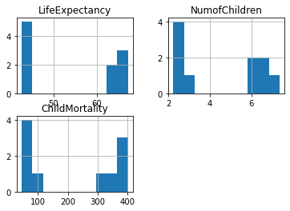

```python
summary.hist()
```

## Exploratory Data Analysis

> **Tip**: Now that you've trimmed and cleaned your data, you're ready to move on to exploration. Compute statistics and create visualizations with the goal of addressing the research questions that you posed in the Introduction section. It is recommended that you be systematic with your approach. Look at one variable at a time, and then follow it up by looking at relationships between variables.

### Research Question 1 - Is there is correlation between life expectancy and a number of children a woman had and the child mortality rate?

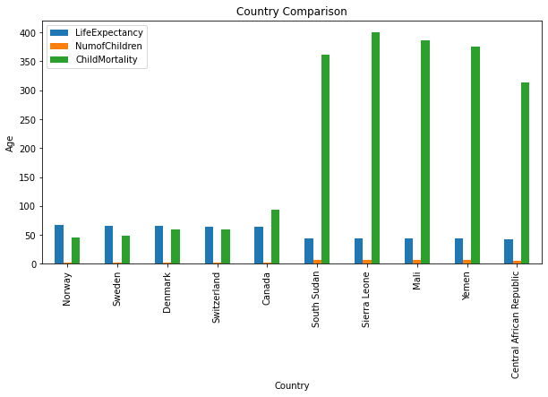

```python
summary.reset_index().plot(x="country", y=["LifeExpectancy", "NumofChildren", "ChildMortality"], kind="bar", figsize=(10,5))
plt.title("Country Comparison")
plt.xlabel("Country")
plt.ylabel("Age")
```

```python
# The bar chart shows a high rate of child mortality amoung the countries with the lowest life expectancy.
```

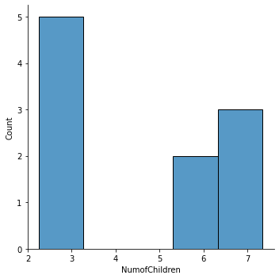

```python
sns.displot(summary['NumofChildren'])
```

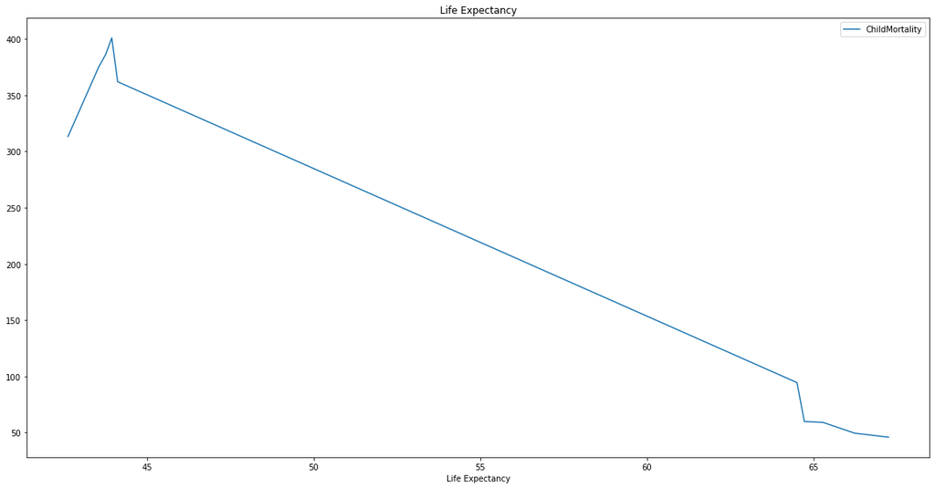

```python
summary.plot(x='LifeExpectancy', y="ChildMortality", kind='line', figsize=(20,10), title="Life Expectancy")
plt.xlabel('Life Expectancy');
```

```python
# This line chart shows the one variable of child mortality in relation to life expectancy. This matches the bar
# chart showing that child mortality is higher on the countries withe the lowest life expectancy mean.
```

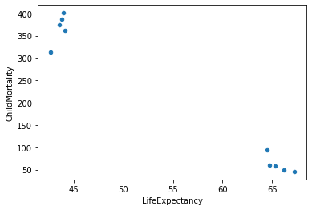

```python
summary.plot.scatter(x='LifeExpectancy', y='ChildMortality')
```

## Conclusions

> **Tip**: Finally, summarize your findings and the results that have been performed. Make sure that you are clear with regards to the limitations of your exploration. If you haven't done any statistical tests, do not imply any statistical conclusions. And make sure you avoid implying causation from correlation!

> **Tip**: Once you are satisfied with your work, you should save a copy of the report in HTML or PDF form via the **File** > **Download as** submenu. Before exporting your report, check over it to make sure that the flow of the report is complete. You should probably remove all of the "Tip" quotes like this one so that the presentation is as tidy as possible. Congratulations!

```python
# My conclusion is it appears there is a correlation between life expectancy and child mortality rate.
# One factor could be that having a high number of deaths with children with young ages pulls down the overall
# life expectancy age of the entire population. There was a limitation in the original data with some countries
# having missing data and thus I had to exclude them from consideration. I would have also like to known if the
# the life expectancy age orginal data include children that died. Did they include everyone from birth till death?
```